# Kite CORT - Assignment 5

M. Richard

October 2, 2019

Lopez-Jimenez, L., J. Blas, A. Tanferna, S. Cabezas, T. Marchant, F. Hiraldo and F. Sergio. 2016. Ambient temperature, body condition and sibling rivalry explain feather corticosterone levels in developing black kites. Functional Ecology 30:605-613.

Authors’ hypothesis: do feather corticosterone (CORT) levels reflect the energetic demands of black kite nestlings during their development?

Sex, brood order, and year were categorical variables. Body condition, territory quality, hatch date, age, and ambient temperature are predictor variables.

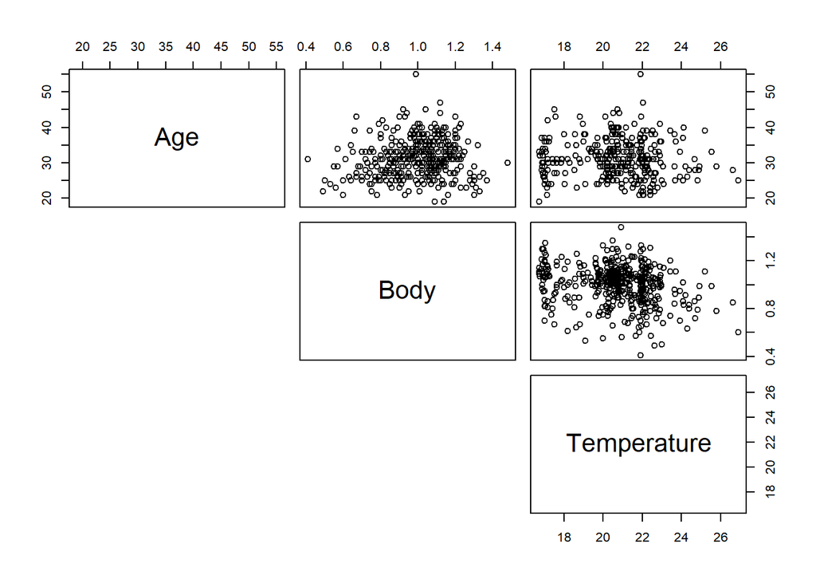

```r
pairs(kites[,3:5], lower.panel = NULL)
```

There does not appear to be any co-linearity between variables.

```r
kite_global <- lm(CORT ~ Age + Body + Temperature , data = kites)
options(na.action = "na.fail")
results<- dredge(kite_global)
results
```

```
## Global model call: lm(formula = CORT ~ Age + Body + Temperature, data = kites)
## ---
## Model selection table
##   (Intrc)     Age   Body   Tmprt df    logLik   AICc delta weight
## 8   34.63 -0.2422 -5.352 -0.5017  5 -1241.076 2492.3  0.00  0.999
## 6   27.63 -0.2570        -0.3991  4 -1248.942 2506.0 13.68  0.001
## 4   23.08 -0.2475 -4.024          4 -1250.577 2509.2 16.95  0.000
## 2   19.41 -0.2583                 3 -1255.093 2516.2 23.95  0.000
## 7   28.14         -6.048 -0.5209  4 -1257.537 2523.2 30.87  0.000
## 5   19.71                -0.4053  3 -1266.879 2539.8 47.52  0.000
## 3   15.98         -4.683          3 -1267.027 2540.1 47.82  0.000
## 1   11.31                         2 -1272.717 2549.5 57.17  0.000
## Models ranked by AICc(x)
```

```r
subset(results, delta <5)
```

```
## Global model call: lm(formula = CORT ~ Age + Body + Temperature, data = kites)
## ---
## Model selection table
##   (Intrc)     Age   Body   Tmprt df    logLik   AICc delta weight
## 8   34.63 -0.2422 -5.352 -0.5017  5 -1241.076 2492.3     0      1
## Models ranked by AICc(x)
```

Subsetting the data doesn’t help to narrow down the top models because there is only one model that is logical given the delta and weight values.

```r
importance(results)
```

```
##                      Age Temperature Body
## Sum of weights:      1   1           1
## N containing models: 4   4           4
```

Looking at the variable weights confirms model 8 as the best model with all three variables having a highest weight possible, 1.

This partically confirms the researchers findings in terms of important varaibles. However, they only provided a partial data set excluding the variables territory quality and hatch date.  
Researchers concluded that CORT increase with decreasing temperature and decreasing body temperature, and CORT levels decreased with age in nestlings with siblings.